# Homework 03

## Question 1: Build an `explain-to-me` skill

Create a small skill named `explain-to-me` that helps you understand a homework question.

1. Design your `SKILL.md` file so that, when you explicitly ask your agent to use the skill to read a homework question, the agent communicates with you and explains what the question is asking.
2. Keep the skill file short. It should contain a few useful rules, instructions, and a clear statement of your intent. For example, you may ask the agent to explain the goal of the question, clarify what work is required, and point you to an appropriate section of the Week 3 lectures: [Ridge Regression: Stability Through Shrinkage](https://teazrq.github.io/stat432rpy/topics/ridge-regression/ridge-regression.html) or [From a Penalized Objective to a Fitted Ridge Model](https://teazrq.github.io/stat432rpy/topics/ridge-regression/optimization-and-cross-validation.html). The skill should help you understand the question without completing the solution for you.
3. Create the skill yourself or with the help of AI. Save it as `explain-to-me/SKILL.md`. Then ask your AI agent to install the skill using its normal skill-installation method. Test it by explicitly asking the agent to use `explain-to-me` to read and explain Question 2.
4. If the skill does not work well, or if it begins to disturb your usual workflow, ask your agent to remove the installed skill. You may revise and reinstall it if you wish.
5. In all cases, append the complete contents of your developed `explain-to-me/SKILL.md` file at the end of your Homework 3 submission under the heading **`explain-to-me` skill**.

## Question 2: Ridge regression with nearly collinear predictors

Let $n=100$. Generate mutually independent standard normal random variables

$$L_i, U_{i1}, U_{i2}, X_{i3}, X_{i4},
\qquad i=1,\ldots,n,$$

and define

$$X_{i1}=L_i+0.04U_{i1},
\qquad
X_{i2}=L_i+0.04U_{i2}.$$

Center and standardize each column of $\mathbf X$ to have mean zero and average squared value one, following the [lecture’s scaling convention](https://teazrq.github.io/stat432rpy/topics/ridge-regression/ridge-regression.html#put-every-covariate-on-a-common-scale).

Continue to use $\mathbf X\in\mathbb R^{n\times p}$ for the standardized matrix and keep it fixed throughout the question, where $p=4$ is the number of predictors. The unpenalized intercept gives $p+1=5$ total fitted coefficients. Let

$$\boldsymbol\beta
=
(1.5,1.5,1,0)^{\mathsf T},
\qquad
\boldsymbol\mu
=
\mathbf X\boldsymbol\beta.$$

Generate a training response and an independent test response at the same predictor values:

$$\begin{aligned}
\mathbf y
&=
\boldsymbol\mu+\boldsymbol\epsilon,\\
\mathbf y^*
&=
\boldsymbol\mu+\boldsymbol\epsilon^*,
\end{aligned}$$

where

$$\boldsymbol\epsilon,
\boldsymbol\epsilon^*
\overset{\mathrm{ind}}{\sim}
\mathcal N_n(\mathbf0,\mathbf I_n).$$

Center the training response as $\widetilde{\mathbf y}=\mathbf y-\bar y\mathbf1_n$. For each $\lambda\in\{0,0.02,0.2\}$, fit the slopes using the lecture’s ridge formula:

$$\widehat{\boldsymbol\beta}_\lambda
=
\left(\mathbf X^{\mathsf T}\mathbf X+n\lambda\mathbf I_p\right)^{-1}
\mathbf X^{\mathsf T}\widetilde{\mathbf y}.$$

The unpenalized intercept is $\widehat\beta_0=\bar y$; add this training mean back when predicting either response. The case $\lambda=0$ is ordinary least squares. Use seed `43231` before generating the design and responses. R and Python use different random-number generators, so their exact numerical results need not agree.

1. Generate $\mathbf X$ once. Report the correlation between its first two columns and its largest and smallest singular values. Use these quantities to explain why the estimator contrast $\widehat\beta_1-\widehat\beta_2$ should be much more variable than $\widehat\beta_1+\widehat\beta_2$.

### a.

**Show the workflow**

```python
import numpy as np

import pandas as pd

np.random.seed(43231)

n = 100

p = 4

L = np.random.normal(size=n)

U1 = np.random.normal(size=n)

U2 = np.random.normal(size=n)

X3 = np.random.normal(size=n)

X4 = np.random.normal(size=n)

X1 = L + 0.04 * U1

X2 = L + 0.04 * U2

X = np.column_stack([X1, X2, X3, X4])

# Center and scale so each column has average squared value 1

X = X - X.mean(axis=0)

X = X / np.sqrt(np.mean(X**2, axis=0))

beta = np.array([1.5, 1.5, 1.0, 0.0])

mu = X @ beta

corr12 = np.corrcoef(X[:, 0], X[:, 1])[0, 1]

singular_values = np.linalg.svd(X, compute_uv=False)

print("Correlation between X1 and X2:", corr12)

print("Largest singular value:", singular_values.max())

print("Smallest singular value:", singular_values.min())
```

```
Correlation between X1 and X2: 0.998268878796455
Largest singular value: 14.151234728892753
Smallest singular value: 0.4134873698774425
```

The correlation between $X_1$ and $X_2$ is very close to 1, and the smallest singular value is much smaller than the largest singular value. This shows that the design matrix is nearly collinear.

Because $X_1$ and $X_2$ are almost the same predictor, the model can change $\widehat\beta_1$ upward and $\widehat\beta_2$ downward without changing the fitted values very much. Therefore, the difference $\widehat\beta_1-\widehat\beta_2$ is poorly determined and should have high variance. In contrast, their sum $\widehat\beta_1+\widehat\beta_2$ determines their combined effect and should be much more stable.

2. Independently repeat the generation of $\mathbf y$ and $\mathbf y^*$, followed by all three fits, 200 times while keeping $\mathbf X$ fixed. Draw the training and test noise inside each repetition, then reuse that realized pair for all three values of $\lambda$. For each value of $\lambda$, report the empirical mean and standard deviation of

$$\widehat\beta_1,
\quad
\widehat\beta_2,
\quad
\widehat\beta_1+\widehat\beta_2,
\quad
\widehat\beta_1-\widehat\beta_2.$$

Also report the average training MSE and the average test MSE calculated from the independent test response, where

$$\operatorname{MSE}_{\mathrm{test}}
=
\frac{1}{n}
\left\lVert
\mathbf y^*
-
\widehat\beta_0\mathbf1_n
-
\mathbf X\widehat{\boldsymbol\beta}
\right\rVert_2^2.$$

### b.

**Show the workflow**

```python
lambdas = [0, 0.02, 0.2]

R = 200

results = []

for r in range(R):

    # Independent training and test responses

    y = mu + np.random.normal(size=n)

    y_test = mu + np.random.normal(size=n)

    y_bar = y.mean()

    y_centered = y - y_bar

    for lam in lambdas:

        beta_hat = np.linalg.solve(

            X.T @ X + n * lam * np.eye(p),

            X.T @ y_centered

        )

        train_pred = y_bar + X @ beta_hat

        test_pred = y_bar + X @ beta_hat

        train_mse = np.mean((y - train_pred)**2)

        test_mse = np.mean((y_test - test_pred)**2)

        results.append({

            "lambda": lam,

            "beta1": beta_hat[0],

            "beta2": beta_hat[1],

            "sum": beta_hat[0] + beta_hat[1],

            "difference": beta_hat[0] - beta_hat[1],

            "train_mse": train_mse,

            "test_mse": test_mse

        })

results = pd.DataFrame(results)

summary = results.groupby("lambda").agg({

    "beta1": ["mean", "std"],

    "beta2": ["mean", "std"],

    "sum": ["mean", "std"],

    "difference": ["mean", "std"],

    "train_mse": "mean",

    "test_mse": "mean"

})

summary.round(4)
```

| lambda | beta1 mean | beta1 std | beta2 mean | beta2 std | sum mean | sum std | difference mean | difference std | train_mse mean | test_mse mean |
| --- | --- | --- | --- | --- | --- | --- | --- | --- | --- | --- |
| 0.00 | 1.4482 | 1.6289 | 1.5505 | 1.6295 | 2.9987 | 0.0919 | -0.1023 | 3.2570 | 0.9332 | 1.0475 |
| 0.02 | 1.4827 | 0.1357 | 1.4871 | 0.1364 | 2.9698 | 0.0910 | -0.0044 | 0.2565 | 0.9421 | 1.0402 |
| 0.20 | 1.3674 | 0.0438 | 1.3649 | 0.0441 | 2.7323 | 0.0835 | 0.0025 | 0.0276 | 1.0420 | 1.1328 |

The results show that OLS has much more variation in the individual estimates $\widehat\beta_1$ and $\widehat\beta_2$. In particular, the standard deviation of $\widehat\beta_1-\widehat\beta_2$ is large because the data have difficulty distinguishing the effects of the two nearly identical predictors.

As $\lambda$ increases, ridge greatly reduces the variability of the individual coefficients and especially their difference. The sum $\widehat\beta_1+\widehat\beta_2$ is much more stable even without much regularization. The training MSE generally increases slightly with stronger regularization, while the test MSE can improve because ridge reduces variance.

3. Interpret the coefficient estimates and test MSE using bias and variance. Explain why ridge can substantially stabilize the individual coefficients without producing an equally large change in the fitted values. ### c.

The results show the bias-variance tradeoff of ridge regression. For OLS ($\lambda=0$), the mean estimates of $\widehat\beta_1$ and $\widehat\beta_2$ are close to their true value of 1.5, but their standard deviations are very large, around 1.63. This happens because $X_1$ and $X_2$ are nearly collinear, so OLS has difficulty determining how much of their shared effect should be assigned to each coefficient.

With ridge regression, the individual coefficients become much more stable. For example, when $\lambda=0.02$, their standard deviations decrease to about 0.14 while their means remain close to 1.5. When $\lambda=0.2$, the standard deviations decrease even further, but the means are more noticeably shrunk toward zero. This demonstrates the bias-variance tradeoff: increasing $\lambda$ introduces more bias but reduces variance.

The sum $\widehat\beta_1+\widehat\beta_2$ is much more stable than the individual coefficients because the data can estimate the combined effect of the two nearly identical predictors well. In contrast, the difference $\widehat\beta_1-\widehat\beta_2$ is unstable under OLS because many different combinations of the two coefficients can give nearly the same fitted values.

Therefore, ridge can substantially stabilize the individual coefficients without changing the fitted values by the same amount. Since $X_1$ and $X_2$ are almost identical, predictions depend mainly on their combined effect rather than how that effect is divided between the two coefficients. A small amount of ridge regularization can therefore reduce variance and improve test performance, while too much regularization can increase bias and hurt prediction.

The results illustrate the bias-variance tradeoff. With OLS, $\widehat\beta_1$ and $\widehat\beta_2$ are approximately unbiased on average, but they can vary greatly between samples because $X_1$ and $X_2$ are nearly collinear. Ridge introduces some bias by shrinking the coefficients toward zero, but it substantially reduces their variance.

The fitted values do not change nearly as much as the individual coefficients because $X_1$ and $X_2$ are almost identical. For example, increasing $\widehat\beta_1$ while decreasing $\widehat\beta_2$ can produce almost the same prediction. Ridge removes much of this unstable coefficient behavior while preserving their combined effect, so it can strongly stabilize the coefficients without causing an equally large change in predictions.

## Question 3: What does ridge regression shrink?

Let $\mathbf X\in\mathbb R^{n\times p}$ be a centered predictor matrix, and let $\widetilde{\mathbf y}\in\mathbb R^n$ be the centered response. Use the supplied predictor scales for this algebraic question; the columns need not have unit variance. Here $p$ counts predictors, $\boldsymbol\beta\in\mathbb R^p$ contains their slopes, and $p+1$ counts all fitted coefficients, including the separately fitted, unpenalized intercept. Ridge regression minimizes

$$L_\lambda(\boldsymbol\beta)
=
\frac{1}{2n}
\left\lVert
\widetilde{\mathbf y}-\mathbf X\boldsymbol\beta
\right\rVert_2^2
+
\frac{\lambda}{2}
\lVert\boldsymbol\beta\rVert_2^2.$$

1. Derive the ridge normal equation

$$\left(
\mathbf X^{\mathsf T}\mathbf X
+n\lambda\mathbf I_p
\right)
\widehat{\boldsymbol\beta}_\lambda
=
\mathbf X^{\mathsf T}\widetilde{\mathbf y}.$$

Explain why it has a unique solution whenever $\lambda>0$, even if $\mathbf X$ is rank deficient or $p>n$. ### a.

The ridge objective is

[output not shown]

Taking the gradient with respect to $\boldsymbol\beta$ gives

Setting the gradient equal to zero,

Multiplying by $n$ and rearranging gives

When $\lambda>0$, for any nonzero vector $\mathbf v$,

[output not shown]

Therefore, $\mathbf X^{\mathsf T}\mathbf X+n\lambda\mathbf I_p$ is positive definite and invertible. This means ridge has a unique solution even if $\mathbf X$ is rank deficient or $p>n$.

2. Let

$$\mathbf X
=
\mathbf U_r\mathbf D_r\mathbf V_r^{\mathsf T}$$

be a compact singular value decomposition, where $r=\operatorname{rank}(\mathbf X)$, $\mathbf U_r\in\mathbb R^{n\times r}$, $\mathbf D_r\in\mathbb R^{r\times r}$, and $\mathbf V_r\in\mathbb R^{p\times r}$. Show that ridge multiplies the fitted response component in the $j$th left singular-vector direction, for $j=1,\ldots,r$, by

$$\rho_j(\lambda)
=
\frac{d_j^2}{d_j^2+n\lambda}.$$

Suppose $n=100$, $\lambda=0.01$, and the nonzero singular values are

$$d_1=10,
\qquad
d_2=2,
\qquad
d_3=0.2.$$

Calculate the three shrinkage factors and the total effective degrees of freedom, including the unpenalized intercept:

$$\operatorname{df}_{\mathrm{eff}}(\lambda)
=
1+\sum_{j=1}^3\rho_j(\lambda).$$

### b.

Using the compact SVD,

X=U_rD_rV_r^{T},

we have

The ridge fitted response can be written as

Using the SVD, this becomes

Therefore, the fitted response in the $j$th singular-vector direction is multiplied by

Here, $n=100$ and $\lambda=0.01$, so

For $d_1=10$,

For $d_2=2$,

For $d_3=0.2$,

Including the unpenalized intercept, the effective degrees of freedom are

3. Which direction receives the strongest shrinkage? Explain why shrinking this direction can reduce prediction variance. Under what circumstance could the same shrinkage produce substantial prediction bias? The third direction, corresponding to $d_3=0.2$, receives the strongest shrinkage because it has the smallest singular value and therefore the smallest shrinkage factor, $\rho_3\approx0.0385$.

A small singular value represents a direction in the predictor space that is weakly determined by the data. Noise in this direction can cause large changes in the estimated coefficients, so strongly shrinking it reduces the variance of the fitted model.

Let $\mathbf X\in\mathbb R^{n\times p}$ be a centered predictor matrix with $p=2$. Its columns need not have unit variance in this question. The intercept is fitted separately and is not penalized. Suppose the two eigenvalues of

$$\mathbf A_0
=
\frac{1}{n}\mathbf X^{\mathsf T}\mathbf X$$

are $9$ and $0.01$. Ridge regression with $\lambda=0.09$ has curvature matrix

$$\mathbf A_\lambda
=
\frac{1}{n}\mathbf X^{\mathsf T}\mathbf X
+
\lambda\mathbf I_p.$$

1. Calculate the condition numbers of $\mathbf A_0$ and $\mathbf A_\lambda$. Explain what the change says about the geometry of the ridge objective. ### a.

The condition number is the ratio of the largest eigenvalue to the smallest eigenvalue. For the unpenalized matrix,

Ridge adds $\lambda=0.09$ to each eigenvalue, so the eigenvalues of $\mathbf A_\lambda$ are

$$

9+0.09=9.09

$$

and

$$

0.01+0.09=0.10.

$$

Therefore,

$$

The condition number decreases from $900$ to $90.9$. Geometrically, the unpenalized objective is very elongated because its curvature is much larger in one direction than the other. Ridge increases the curvature in the flatter direction, making the objective more rounded and better conditioned. This makes optimization easier.

2. Gradient descent uses

$$\boldsymbol\beta^{(k+1)}
=
\boldsymbol\beta^{(k)}
-
\eta\nabla L_\lambda\!\left(\boldsymbol\beta^{(k)}\right).$$

Let $\widehat{\boldsymbol\beta}_\lambda$ be the ridge minimizer and define the optimization error

$$\mathbf e^{(k)}
=
\boldsymbol\beta^{(k)}
-
\widehat{\boldsymbol\beta}_\lambda.$$

Show that the component of $\mathbf e^{(k)}$ in an eigendirection with unpenalized eigenvalue $a$ is multiplied at each step by

$$1-\eta(a+\lambda).$$

Let $M=9.09$, the largest eigenvalue of $\mathbf A_\lambda$. Find the interval of step sizes that contracts every eigendirection. Then compare these two choices:

- For $\eta=1/M$, calculate the two contraction factors and explain which direction converges faster.
- For $\eta=2.1/M$, determine whether the method converges. Assume the initial error has a nonzero component in the eigendirection corresponding to $M$. ### b.

Because the ridge objective is quadratic, its gradient can be written as

Since

the gradient descent update gives

In an eigendirection whose unpenalized eigenvalue is $a$, the corresponding ridge eigenvalue is $a+\lambda$. Therefore, the error component in that direction is multiplied at each step by

For gradient descent to contract in every direction, we need

The largest ridge eigenvalue is $M=9.09$, so the required interval is

For $\eta=1/M=1/9.09$, the contraction factor for the direction with eigenvalue $9.09$ is

For the direction with ridge eigenvalue $0.10$,

Therefore, the high-curvature direction converges immediately, while the low-curvature direction converges much more slowly because its contraction factor is close to 1.

For $\eta=2.1/M$,

In the direction corresponding to the largest eigenvalue,

Since

[output not shown]

the error grows in magnitude in this direction. Because the initial error is assumed to have a nonzero component in this direction, gradient descent does not converge. Instead, that component oscillates in sign while increasing in magnitude.

3. Increasing $\lambda$ generally improves the condition number. Explain why choosing $\lambda$ to make gradient descent converge as quickly as possible is not a valid statistical tuning rule. ### c.

Although increasing $\lambda$ improves the condition number and can make gradient descent converge faster, computational speed is not the main goal when choosing the ridge penalty. The value of $\lambda$ also determines how strongly the estimated coefficients are shrunk.

A very large $\lambda$ may make optimization easy, but it can shrink important signal too much and create substantial prediction bias. Therefore, $\lambda$ should be chosen based on statistical prediction performance, such as with cross-validation, rather than simply choosing the value that gives the fastest gradient descent convergence.

## Question 5: Selecting the ridge penalty for real-estate prediction

The supplied `data/realestate.csv` contains 414 real-estate transactions from Sindian District, New Taipei City, Taiwan. The quantitative response `price` is the unit house price. The six predictors are the transaction date, house age, distance to the nearest mass rapid transit station, number of nearby convenience stores, latitude, and longitude. Treat all six predictors as quantitative in this question. The column `row_id` identifies an observation and must not be used as a predictor.

The file `data/realestate-split-folds.csv` assigns 332 observations to the training set and 82 observations to the final test set. It also gives ten fold labels for the training observations. Match the two files using `row_id` and do not use the test responses while selecting a model.

Use the penalty grid

$$\Lambda
=
\{0\}
\mathbin{\cup}
\left\{
10^{-4+0.05l}:l=0,\ldots,120
\right\}.$$

For every fit, center and standardize each predictor using only the observations available to that fit, with the variance divided by the number of fitting observations. Center the response and leave the intercept unpenalized.

1. Perform ten-fold cross-validation over $\Lambda$ using the supplied training folds. Estimate the predictor means and scales separately within each set of nine training folds. For each $\lambda$, calculate the mean validation MSE and $\operatorname{SE}(\lambda)$, the sample standard deviation of the ten fold errors divided by $\sqrt{10}$. Use this SE for the conventional one-standard-error heuristic. Plot the mean validation MSE and identify $\lambda_{\min}$. Choose $\lambda_{\mathrm{1se}}$ as the largest candidate in $\Lambda$, including OLS, satisfying

$$\overline{\operatorname{MSE}}(\lambda)
\leq
\overline{\operatorname{MSE}}(\lambda_{\min})
+
\operatorname{SE}(\lambda_{\min}).$$

**Show the workflow**

```python
import numpy as np
import pandas as pd
import matplotlib.pyplot as plt

data = pd.read_csv("data/realestate.csv")
folds = pd.read_csv("data/realestate-split-folds.csv")

df = data.merge(folds, on="row_id")

print(df.columns)
```

```
Index(['row_id', 'date', 'age', 'distance', 'stores', 'latitude', 'longitude',
       'price', 'split', 'cv_fold'],
      dtype='object')
```

**Show the workflow**

```
lambda_min: 0.01995262314968881
lambda_1se: 1.584893192461114
```

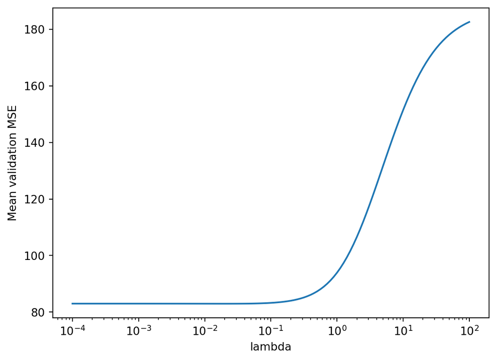

```python
features = ["date","age","distance","stores","latitude","longitude"]
train = df[df["split"]=="train"]
lambdas = np.r_[0, 10**(-4+0.05*np.arange(121))]
errors = np.zeros((10,len(lambdas)))

for k in range(1,11):
    tr, va = train[train.cv_fold!=k], train[train.cv_fold==k]
    X, Xv = tr[features].values, va[features].values
    y, yv = tr.price.values, va.price.values

    m, s = X.mean(0), X.std(0)
    X, Xv = (X-m)/s, (Xv-m)/s
    ybar = y.mean()

    for j, lam in enumerate(lambdas):
        b = np.linalg.solve(X.T@X + len(y)*lam*np.eye(6), X.T@(y-ybar))
        errors[k-1,j] = np.mean((yv-(ybar+Xv@b))**2)

mse = errors.mean(0)
se = errors.std(0,ddof=1)/np.sqrt(10)

i = np.argmin(mse)
lambda_min = lambdas[i]
lambda_1se = lambdas[mse <= mse[i]+se[i]][-1]

print("lambda_min:", lambda_min)
print("lambda_1se:", lambda_1se)

plt.plot(lambdas[1:],mse[1:])
plt.xscale("log")
plt.xlabel("lambda")
plt.ylabel("Mean validation MSE")
plt.show()
```

2. Use all $n=332$ training observations to calculate the [lecture’s GCV criterion](https://teazrq.github.io/stat432rpy/topics/ridge-regression/optimization-and-cross-validation.html#loocv-and-gcv) for each $\lambda\in\Lambda$:

$$\operatorname{GCV}(\lambda)
=
\frac{
\operatorname{MSE}_{\mathrm{train}}(\lambda)
}{
\left\{
1-\operatorname{df}_{\mathrm{eff}}(\lambda)/n
\right\}^2
}.$$

Here $\operatorname{MSE}_{\mathrm{train}}$ is the training MSE, and $\operatorname{df}_{\mathrm{eff}}$ includes the unpenalized intercept, as in Question 3. Estimate means and scales once from all training observations and keep them fixed for this calculation. Plot the GCV curve and identify $\lambda_{\mathrm{GCV}}$.

### b.

**Show the workflow**

```
lambda_GCV: 0.02818382931264455
```

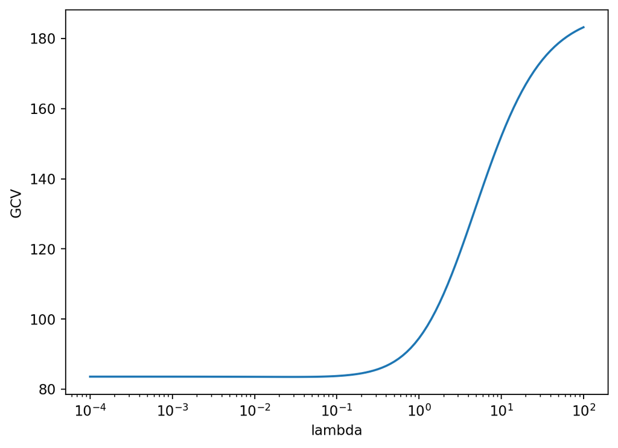

```python
X = train[features].values
y = train.price.values
n = len(y)

X = (X-X.mean(0))/X.std(0)
ybar = y.mean()
d = np.linalg.svd(X, compute_uv=False)

gcv = []

for lam in lambdas:
    b = np.linalg.solve(X.T@X+n*lam*np.eye(6), X.T@(y-ybar))
    mse = np.mean((y-(ybar+X@b))**2)
    df = 1 + np.sum(d**2/(d**2+n*lam))
    gcv.append(mse/(1-df/n)**2)

gcv = np.array(gcv)
lambda_gcv = lambdas[np.argmin(gcv)]

print("lambda_GCV:", lambda_gcv)

plt.plot(lambdas[1:], gcv[1:])
plt.xscale("log")
plt.xlabel("lambda")
plt.ylabel("GCV")
plt.show()
```

3. Fix all three choices before examining the test responses. Refit OLS and ridge at $\lambda_{\min}$, $\lambda_{\mathrm{1se}}$, and $\lambda_{\mathrm{GCV}}$ using all training observations. Report each model’s training MSE, test MSE, and effective degrees of freedom. Interpret the differences and explain why the model with the smallest observed test MSE must not be selected after viewing this table.

### c.

**Show the workflow**

```python
df = data.merge(folds, on="row_id")

test = df[df["split"]=="test"]

Xtest = (test[features].values - train[features].values.mean(0)) / train[features].values.std(0)

ytest = test.price.values

results = []

for name, lam in [("OLS",0), ("CV min",lambda_min),

                  ("1-SE",lambda_1se), ("GCV",lambda_gcv)]:

    b = np.linalg.solve(X.T@X+n*lam*np.eye(6), X.T@(y-ybar))

    train_mse = np.mean((y-(ybar+X@b))**2)

    test_mse = np.mean((ytest-(ybar+Xtest@b))**2)

    df_eff = 1 + np.sum(d**2/(d**2+n*lam))

    results.append([name, lam, train_mse, test_mse, df_eff])

pd.DataFrame(results, columns=["Model","lambda","Train MSE","Test MSE","df"]).round(4)
```

|  | Model | lambda | Train MSE | Test MSE | df |
| --- | --- | --- | --- | --- | --- |
| 0 | OLS | 0.0000 | 80.0939 | 66.3225 | 7.0000 |
| 1 | CV min | 0.0200 | 80.1354 | 65.9996 | 6.7732 |
| 2 | 1-SE | 1.5849 | 100.3736 | 81.1998 | 3.0329 |
| 3 | GCV | 0.0282 | 80.1713 | 65.9028 | 6.6887 |

As $\lambda$ increases, ridge shrinks the model and reduces its effective degrees of freedom. This can slightly increase training MSE while reducing variance and potentially improving test performance.

The test set should only be used for final evaluation. We cannot choose the model with the smallest test MSE after seeing these results because that would use the test data for model selection, making the reported test performance optimistically biased.

## Reference

The real-estate data come from I-Cheng Yeh’s [Real Estate Valuation dataset](https://archive.ics.uci.edu/dataset/477/real%2Bestate%2Bvaluation%2Bda) in the UCI Machine Learning Repository. The distributed data retain the original observations and add only the course train-test and fold assignments.